# Cx4073 : Assignment 3

Lim Hyun Jeong, A Priyanka, Vinupriya Subramaniyam

U1521499J U1522958L, U1522959H

### Finding Market Segments in Online Retail

```r
retailData <- read.csv("assign3_RetailData.csv", header = TRUE)
str(retailData)
```

```
## 'data.frame':    541909 obs. of  8 variables:
##  $ 癤풦nvoiceNo: Factor w/ 25900 levels "536365","536366",..: 1 1 1 1 1 1 1 2 2 3 ...
##  $ StockCode   : Factor w/ 4070 levels "10002","10080",..: 3538 2795 3045 2986 2985 1663 801 1548 1547 3306 ...
##  $ Description : Factor w/ 4224 levels ""," 4 PURPLE FLOCK DINNER CANDLES",..: 4027 4035 932 1959 2980 3235 1573 1698 1695 259 ...
##  $ Quantity    : int  6 6 8 6 6 2 6 6 6 32 ...
##  $ InvoiceDate : Factor w/ 23260 levels "1/11/11 10:01",..: 198 198 198 198 198 198 198 199 199 200 ...
##  $ UnitPrice   : num  2.55 3.39 2.75 3.39 3.39 7.65 4.25 1.85 1.85 1.69 ...
##  $ CustomerID  : int  17850 17850 17850 17850 17850 17850 17850 17850 17850 13047 ...
##  $ Country     : Factor w/ 38 levels "Australia","Austria",..: 36 36 36 36 36 36 36 36 36 36 ...
```

The following table summarizes the variables in the dataset. Note the type carefully, and convert if required.

| Variable | Description | Remarks |
| --- | --- | --- |
| InvoiceNo | The serial number on the Invoice | May be different for same product and same customer. |
| StockCode | Product (item) code in the Store | Uniquely assigned to every distinct Product (item). |
| Description | Product (item) name in the Store | May be different for the same StockCode. Do check. |
| Quantity | Product Quantity in the Transaction | Will of course change with different transactions. |
| InvoiceDate | Date-Time of the Transaction | Can you use this too? Try, but it is strictly optional. |
| UnitPrice | Product Price per Unit (in Dollars) | Should be the same for the same Product. Do check. |
| CustomerID | Customer code in the Store | Same customer may make various purchases. Check carefully. |
| Country | Country of Residence of Customer | Should be the same for each individual Customer. |

Hint : Think of creating a Customer-Product matrix before you start your market segmentation. First step is deciding the elements in the matrix, and the second step if to choose the notion of distance that whould be appropriate for this case. See if you can effectively use the variables like `Quantity`, `UnitPrice`, `InvoiceDate` and `Country` in this market segmentation. Don’t forget to interpret the market segments that you get!

**Continue with Data Exploration, creation of Customer-Product matrix, choice of Distance, various Clustering algorithms, and Interpretation. Submit this .Rmd file as your Solution : [StudentID1_StudentID2_StudentID3].Rmd, where the three StudentIDs are the Matriculation Numbers of the three students in your team. Change the filename appropriately if you have less than three members in your team.**

```r
#install.packages("dplyr")
```

#### Summary of Data

```r
summary(retailData)
```

```
##   癤풦nvoiceNo      StockCode
##  573585 :  1114   85123A :  2313
##  581219 :   749   22423  :  2203
##  581492 :   731   85099B :  2159
##  580729 :   721   47566  :  1727
##  558475 :   705   20725  :  1639
##  579777 :   687   84879  :  1502
##  (Other):537202   (Other):530366
##                              Description        Quantity
##  WHITE HANGING HEART T-LIGHT HOLDER:  2369   Min.   :-80995.00
##  REGENCY CAKESTAND 3 TIER          :  2200   1st Qu.:     1.00
##  JUMBO BAG RED RETROSPOT           :  2159   Median :     3.00
##  PARTY BUNTING                     :  1727   Mean   :     9.55
##  LUNCH BAG RED RETROSPOT           :  1638   3rd Qu.:    10.00
##  ASSORTED COLOUR BIRD ORNAMENT     :  1501   Max.   : 80995.00
##  (Other)                           :530315
##          InvoiceDate       UnitPrice           CustomerID
##  31/10/11 14:41:  1114   Min.   :-11062.06   Min.   :12346
##  8/12/11 9:28  :   749   1st Qu.:     1.25   1st Qu.:13953
##  9/12/11 10:03 :   731   Median :     2.08   Median :15152
##  5/12/11 17:24 :   721   Mean   :     4.61   Mean   :15288
##  29/6/11 15:58 :   705   3rd Qu.:     4.13   3rd Qu.:16791
##  30/11/11 15:13:   687   Max.   : 38970.00   Max.   :18287
##  (Other)       :537202                       NA's   :135080
##            Country
##  United Kingdom:495478
##  Germany       :  9495
##  France        :  8557
##  EIRE          :  8196
##  Spain         :  2533
##  Netherlands   :  2371
##  (Other)       : 15279
```

```r
head(retailData)
```

```
##   癤풦nvoiceNo StockCode                         Description Quantity
## 1       536365    85123A  WHITE HANGING HEART T-LIGHT HOLDER        6
## 2       536365     71053                 WHITE METAL LANTERN        6
## 3       536365    84406B      CREAM CUPID HEARTS COAT HANGER        8
## 4       536365    84029G KNITTED UNION FLAG HOT WATER BOTTLE        6
## 5       536365    84029E      RED WOOLLY HOTTIE WHITE HEART.        6
## 6       536365     22752        SET 7 BABUSHKA NESTING BOXES        2
##    InvoiceDate UnitPrice CustomerID        Country
## 1 1/12/10 8:26      2.55      17850 United Kingdom
## 2 1/12/10 8:26      3.39      17850 United Kingdom
## 3 1/12/10 8:26      2.75      17850 United Kingdom
## 4 1/12/10 8:26      3.39      17850 United Kingdom
## 5 1/12/10 8:26      3.39      17850 United Kingdom
## 6 1/12/10 8:26      7.65      17850 United Kingdom
```

```r
tail(retailData)
```

```
##        癤풦nvoiceNo StockCode                     Description Quantity
## 541904       581587     23256     CHILDRENS CUTLERY SPACEBOY         4
## 541905       581587     22613     PACK OF 20 SPACEBOY NAPKINS       12
## 541906       581587     22899    CHILDREN'S APRON DOLLY GIRL         6
## 541907       581587     23254   CHILDRENS CUTLERY DOLLY GIRL         4
## 541908       581587     23255 CHILDRENS CUTLERY CIRCUS PARADE        4
## 541909       581587     22138   BAKING SET 9 PIECE RETROSPOT         3
##          InvoiceDate UnitPrice CustomerID Country
## 541904 9/12/11 12:50      4.15      12680  France
## 541905 9/12/11 12:50      0.85      12680  France
## 541906 9/12/11 12:50      2.10      12680  France
## 541907 9/12/11 12:50      4.15      12680  France
## 541908 9/12/11 12:50      4.15      12680  France
## 541909 9/12/11 12:50      4.95      12680  France
```

#### Data Pre-processing

```r
library(dplyr)
df<-filter(retailData,Description!="[A-Z].*")
df1<-filter(df,Description!="SAMPLES")
df2<-filter(df1,Quantity>0 )
df3<-filter(df2,UnitPrice>0)
df4<-filter(df3,Description!="Manual")
df5<-filter(df4,Description!="Adjust bad debt")
df6<-filter(df5,Description!="Next Day Carriage")
df7<-filter(df6,CustomerID!="NA")
df7<-filter(df7,Country != "Unspecified")
# write.csv(df7,'retaildataNew2.csv')
```

Some data pre-processing has been performed to handle inconsistent data, missing values and irrelevant data.

- The `Description` with different format was found to be inconsistent with the stock code. (e.g. Stock code 20711 - JUMBO BAG TOYS, inconsistent name - lost in space). Since there were very few of these inconsistent data, and removing them would not affect the dataset significantly, the items with inconsistent description were removed.
- Samples are not very relevant in this analysis as they are freely given out to the customers when they purchase another product, as a marketing strategy. Also, the customer’s decision to buy a product depends more heavily on their need for the product, rather than what samples come with it. Therefore, the samples would not affect the customer’s purchase decision significantly, thus they were excluded from the dataset.
- Those items with negative `Qantity` or `Unit Price` were also removed as it is impossible to have a product sold for negative quantity or unit price
- Manuals are add-ons to the products the customers purchase. Therefore, it is highly correlated to the product it is tied to, therefore does not add much information to the analysis. Thus, manuals were also removed from the dataset.
- Items with `Description` such as “Adjust bad debt” or “Next Day Carriage” were also excluded as they are not product’s names and are inconsistent with the dataset.
- Items with missing `CustomerID` were also removed from the dataset, as `CustomerID` is a key feature used for clustering.
- Items with unspecified country were also removed as country of residence is important in understanding the purchase pattern of the customers.

#### Removing Anomalies

Removing anomalies is important as anomalies can affect the clustering. Removing anomalies can make the clustering process more efficient.

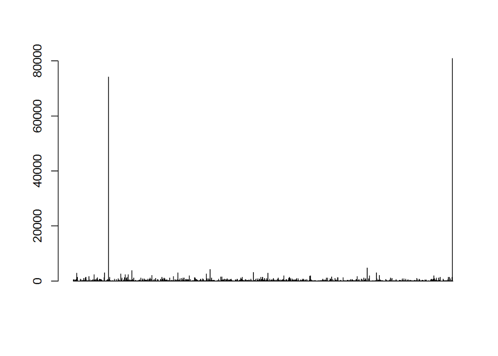

```r
barplot(df7$Quantity, col = "blue")
```

From the barplot above, there are 2 anomalies of `Quantity` > 20000. These were removed.

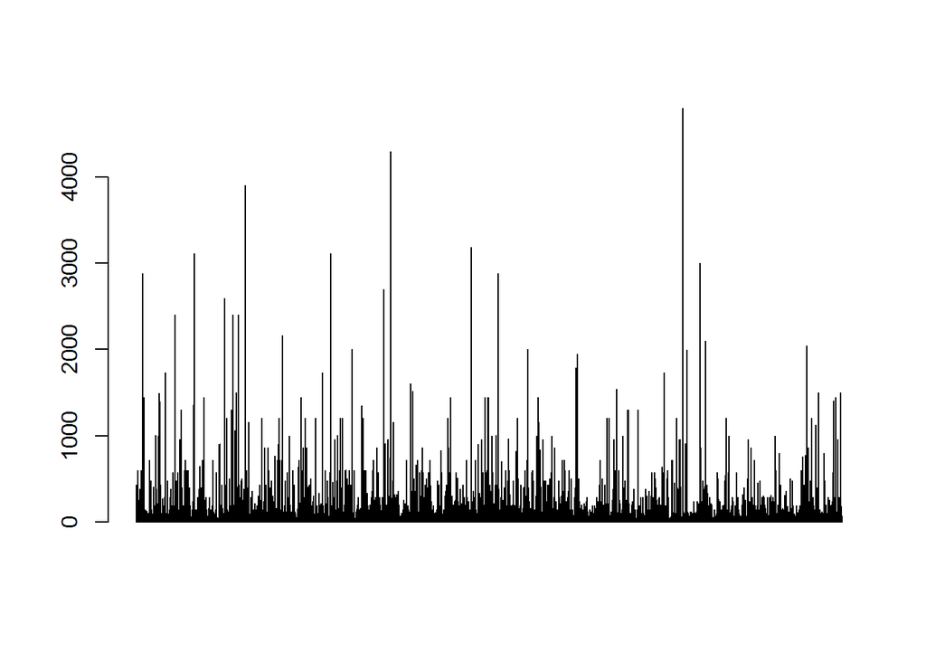

```r
df7<-filter(df7,Quantity<20000 )
barplot(df7$Quantity, col = "blue")
```

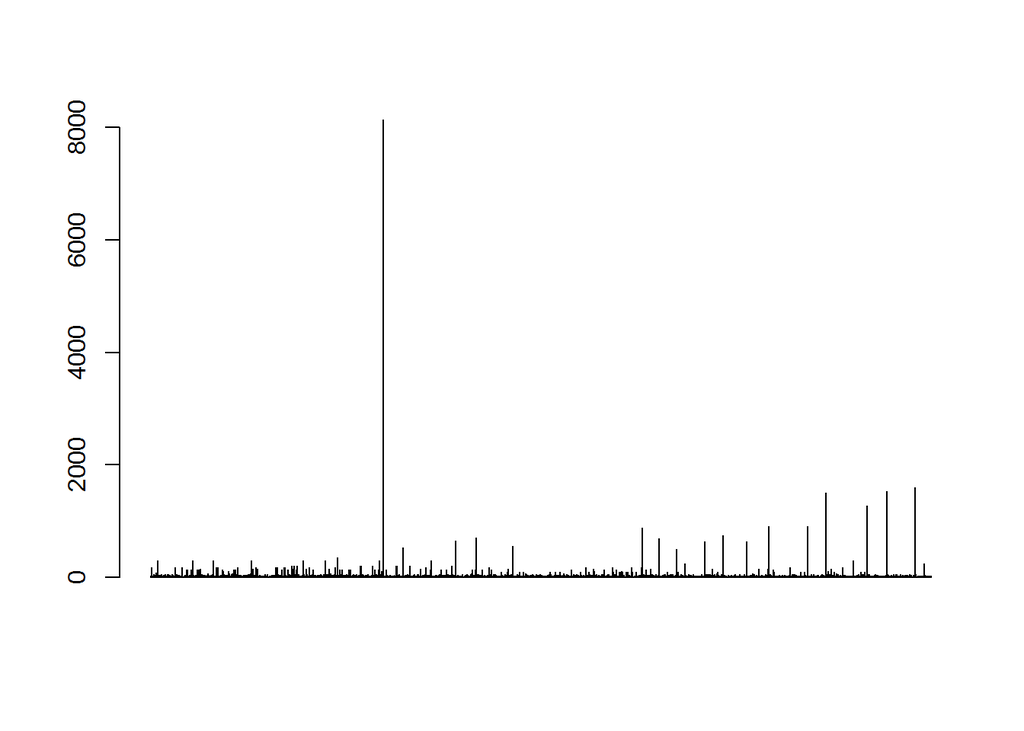

```r
barplot(df7$UnitPrice, col = "blue")
```

From the barplot above, there is an anomaly of `UnitPrice` > 3000. This data point was also removed.

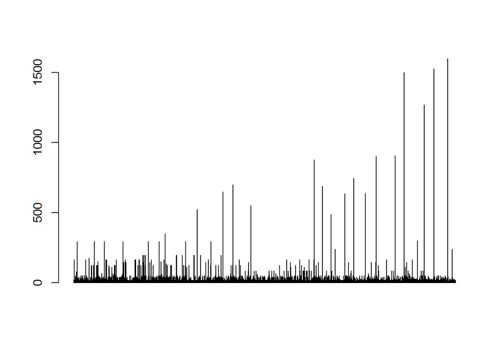

```r
df7<-filter(df7,UnitPrice<3000 )
barplot(df7$UnitPrice, col = "blue")
```

#### Extracting 1000 most frequent items

```r
t2 <- subset(df7, select = c("StockCode"))
countt2 <- table(unlist(t2))
countt2df<-as.data.frame(countt2)
colnames(countt2df) <- c("StockCode", "Freq")

countt2dfSort <- countt2df[rev(order(countt2df$Freq)),]

mostFreqProducts <- countt2dfSort[1:1000, "StockCode"]

mostFreqProductsExtracted <- df7[is.element(df7$StockCode, mostFreqProducts),]
head(mostFreqProductsExtracted)
```

```
##   癤풦nvoiceNo StockCode                         Description Quantity
## 1       536365    85123A  WHITE HANGING HEART T-LIGHT HOLDER        6
## 2       536365     71053                 WHITE METAL LANTERN        6
## 3       536365    84406B      CREAM CUPID HEARTS COAT HANGER        8
## 4       536365    84029G KNITTED UNION FLAG HOT WATER BOTTLE        6
## 5       536365    84029E      RED WOOLLY HOTTIE WHITE HEART.        6
## 6       536365     22752        SET 7 BABUSHKA NESTING BOXES        2
##    InvoiceDate UnitPrice CustomerID        Country
## 1 1/12/10 8:26      2.55      17850 United Kingdom
## 2 1/12/10 8:26      3.39      17850 United Kingdom
## 3 1/12/10 8:26      2.75      17850 United Kingdom
## 4 1/12/10 8:26      3.39      17850 United Kingdom
## 5 1/12/10 8:26      3.39      17850 United Kingdom
## 6 1/12/10 8:26      7.65      17850 United Kingdom
```

```r
# write.csv(mostFreqProductsExtracted,'extracted.csv')
```

Using the `StockCode`, 1000 most popular items sold were extracted. The 1000 most popular items were used as they were probably generating the most revenue for the store, and it is logical to focus the marketing efforts for these most popular items.

#### Creating Customer-Product matrix

```r
xtabs(Quantity ~ CustomerID + StockCode, data = mostFreqProductsExtracted, addNA = TRUE, sparse = TRUE)
```

```
## 4282 x 4070 sparse Matrix of class "dgCMatrix"
```

```
##    [[ suppressing 30 column names '10002', '10080', '10120' ... ]]
##    [[ suppressing 30 column names '10002', '10080', '10120' ... ]]
```

[output not shown]

[output cut: 1657 more lines]

```
##    [[ suppressing 30 column names '10002', '10080', '10120' ... ]]
```

[output not shown]

[output cut: 1652 more lines]

```r
#install.packages("mclust")
```

#### Clustering

For clustering, we used K-Means Clustering algorithm.

A 4 relevant columns were extracted for the analysis: * `StockCode` : Stock code is essential to understand how many of which products are being sold.  
* `Quantity` : Quantity can help us to understand the purchase pattern customers have on each product. Some products would more likely to be sold as a bulk. * `CustomerID` : Customer ID is also essential in understanding the customer’s purchase pattern * `Country` : Country is also important as customers from different countries might have different purchase patterns, for reasons such as differences in culture, GDP, preferences, etc.

```r
clusterColumns <- subset(mostFreqProductsExtracted, select = c("StockCode", "Quantity", "CustomerID", "Country"))

summary(clusterColumns)
```

```
##    StockCode         Quantity         CustomerID
##  85123A :  2035   Min.   :   1.00   Min.   :12347
##  22423  :  1721   1st Qu.:   2.00   1st Qu.:13924
##  85099B :  1618   Median :   6.00   Median :15159
##  84879  :  1405   Mean   :  12.93   Mean   :15287
##  47566  :  1396   3rd Qu.:  12.00   3rd Qu.:16782
##  20725  :  1317   Max.   :4800.00   Max.   :18287
##  (Other):289734
##            Country
##  United Kingdom:266097
##  Germany       :  6997
##  France        :  6716
##  EIRE          :  5265
##  Netherlands   :  1912
##  Spain         :  1802
##  (Other)       : 10437
```

```r
str(clusterColumns)
```

```
## 'data.frame':    299226 obs. of  4 variables:
##  $ StockCode : Factor w/ 4070 levels "10002","10080",..: 3538 2795 3045 2986 2985 1663 1548 1547 3306 1656 ...
##  $ Quantity  : int  6 6 8 6 6 2 6 6 32 6 ...
##  $ CustomerID: int  17850 17850 17850 17850 17850 17850 17850 17850 13047 13047 ...
##  $ Country   : Factor w/ 38 levels "Australia","Austria",..: 36 36 36 36 36 36 36 36 36 36 ...
```

As K-Means clustering only works for numeric values, non-numeric values (`StockCode`, `Country`) were given numeric indexes for clustering purpose.

```r
clusterColumns$numStockCode <- as.numeric(clusterColumns$StockCode)
clusterColumns$numCountry <- as.numeric(clusterColumns$Country)

summary(clusterColumns)
```

```
##    StockCode         Quantity         CustomerID
##  85123A :  2035   Min.   :   1.00   Min.   :12347
##  22423  :  1721   1st Qu.:   2.00   1st Qu.:13924
##  85099B :  1618   Median :   6.00   Median :15159
##  84879  :  1405   Mean   :  12.93   Mean   :15287
##  47566  :  1396   3rd Qu.:  12.00   3rd Qu.:16782
##  20725  :  1317   Max.   :4800.00   Max.   :18287
##  (Other):289734
##            Country        numStockCode    numCountry
##  United Kingdom:266097   Min.   :  15   Min.   : 1.00
##  Germany       :  6997   1st Qu.:1023   1st Qu.:36.00
##  France        :  6716   Median :1574   Median :36.00
##  EIRE          :  5265   Mean   :1619   Mean   :33.83
##  Netherlands   :  1912   3rd Qu.:2102   3rd Qu.:36.00
##  Spain         :  1802   Max.   :4069   Max.   :38.00
##  (Other)       : 10437
```

```r
clusterColumns2 <- subset(clusterColumns, select = c("numStockCode", "Quantity", "CustomerID", "numCountry"))
```

**1. Stock Code & Country**

Features `StockCode` and `Country` were selected to understand what kind of products are sold frequently in which countries. Different numbers of clusters were experimented and plotted to determine the optimum number of clusters. Let K be the final number of clusters.

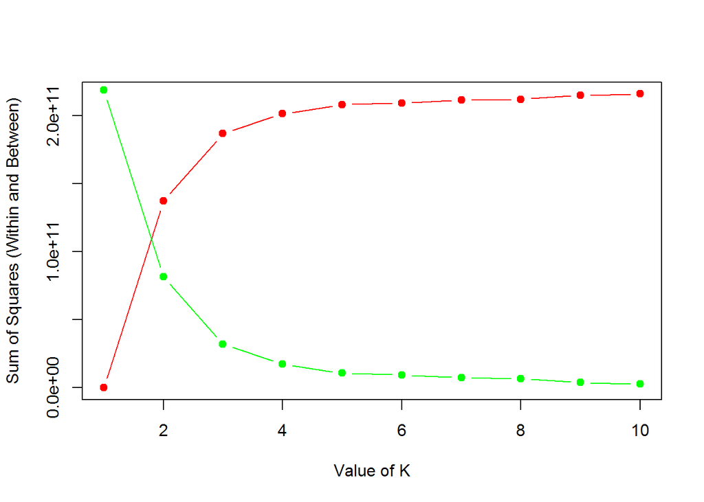

```r
clusterColumns3 <- subset(clusterColumns, select = c("numStockCode", "numCountry"))
kMin <- 1
kMax <- 10
withinSS <- double(kMax - kMin + 1)
betweenSS <- double(kMax - kMin + 1)
for (K in kMin:kMax) {
  kMeansFit <-  kmeans(clusterColumns3, centers = K)
  withinSS[K] <- sum(kMeansFit$withinss)
  betweenSS[K] <- kMeansFit$betweenss
}
plot(kMin:kMax, betweenSS, pch=19, type="b", col="red",
     xlab = "Value of K", ylab = "Sum of Squares (Within and Between)")
points(kMin:kMax, withinSS, pch=19, type="b", col="green")
```

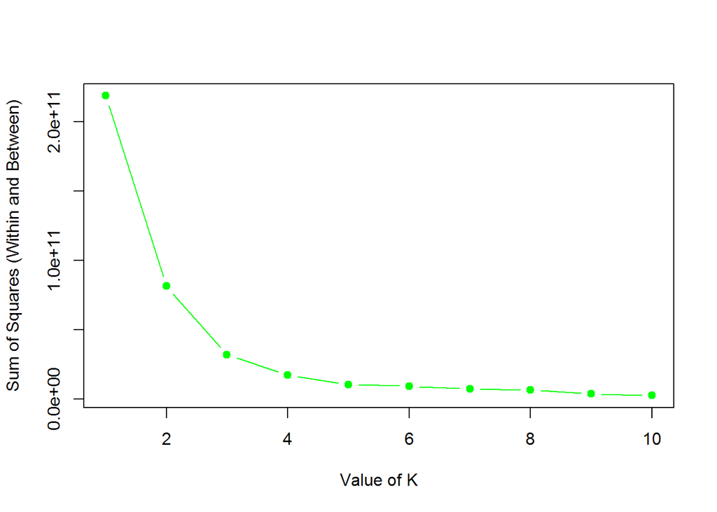

```r
plot(kMin:kMax, withinSS, pch=19, type="b", col="green",
     xlab = "Value of K", ylab = "Sum of Squares (Within and Between)")
```

To evaluate the clusters, Within Sum of Squres and Between Sum of Squares were used. From the plots above, we can see that the Within Sum of Squares (Green line) drops drastically until K = 5 until almost 0 and plateus. At K = 5, the Between Sum of Squares (Red line) increases drastically and beyond K = 5 the value plateus. Therefore, the optimal number of clusters is 5.

Therefore, 5 clusters were created.

```r
K <- 5
kMeansFit <- kmeans(clusterColumns3, centers = K, nstart = 20)

# Note that the labels are stored as follows
clusterColumns3$cluster <- kMeansFit$cluster
```

These 5 clusters were then separated for deeper analysis.

```r
mostFreqProductsExtracted$numStockCode <- clusterColumns$numStockCode
mostFreqProductsExtracted$numCountry <- clusterColumns$numCountry
mostFreqProductsExtracted$cluster <- clusterColumns3$cluster

#sort by cluster & write to file

clsuterProductCountry <- mostFreqProductsExtracted[order(mostFreqProductsExtracted$cluster),]

# write.csv(clsuterProductCountry,'clusterProductCustomer.csv')

# separate each cluster into diff dataframe

allProductCountryClusters <- read.csv("clusterProductCustomer.csv", header = TRUE)

clusterLabels <- allProductCountryClusters$cluster

productCountryCluster1 <- allProductCountryClusters[clusterLabels == 1,]
productCountryCluster2 <- allProductCountryClusters[clusterLabels == 2,]
productCountryCluster3 <- allProductCountryClusters[clusterLabels == 3,]
productCountryCluster4 <- allProductCountryClusters[clusterLabels == 4,]
productCountryCluster5 <- allProductCountryClusters[clusterLabels == 5,]
```

- Cluster 1

Top 10 most frequently sold products from cluster1 was extracted.

```r
cluster1 <- subset(productCountryCluster1, select = c("StockCode"))
clutercount1 <- table(unlist(cluster1))
count1<-as.data.frame(clutercount1)
colnames(count1) <- c("StockCode", "Freq")

sortcluster1 <- count1[rev(order(count1$Freq)),]

top10cluster1 <- sortcluster1[1:10, "StockCode"]

top10cluster1extracted <- productCountryCluster1[is.element(productCountryCluster1$StockCode, top10cluster1),]
```

```r
descriptions1 <- unique(top10cluster1extracted$Description)
descriptions1
```

```
##  [1] JAM MAKING SET WITH JARS          JAM MAKING SET PRINTED
##  [3] SET OF 4 PANTRY JELLY MOULDS      LUNCH BAG APPLE DESIGN
##  [5] SPOTTY BUNTING                    BUNTING , SPOTTY
##  [7] LUNCH BAG DOILEY PATTERN          JUMBO BAG DOILEY PATTERNS
##  [9] JUMBO BAG VINTAGE LEAF            RABBIT NIGHT LIGHT
## [11] GARDENERS KNEELING PAD KEEP CALM  JUMBO BAG VINTAGE DOILEY
## [13] JUMBO BAG VINTAGE DOILY           LUNCH BAG VINTAGE DOILY
## [15] LUNCH BAG VINTAGE DOILEY
## 1110 Levels:  DOLLY GIRL BEAKER ... ZINC WILLIE WINKIE  CANDLE STICK
```

```r
price1 <- unique(top10cluster1extracted$UnitPrice)
price1
```

```
##  [1] 4.25 1.45 3.75 1.25 1.06 1.65 4.95 4.15 2.08 1.95 1.79 2.96 1.18 1.75
## [15] 1.43 5.14 4.60 3.29 8.29 2.46 2.95 4.13 1.67 1.48 1.38
```

```r
country1 <- unique(top10cluster1extracted$Country)
country1
```

```
##  [1] United Kingdom     Norway             Germany
##  [4] Poland             France             Denmark
##  [7] Japan              Portugal           EIRE
## [10] Netherlands        Spain              Australia
## [13] Belgium            Singapore          Italy
## [16] Lebanon            Cyprus             Channel Islands
## [19] Finland            Austria            Switzerland
## [22] Brazil             Sweden             USA
## [25] European Community Iceland            Canada
## [28] Greece             Malta              Israel
## [31] RSA
## 36 Levels: Australia Austria Bahrain Belgium Brazil ... USA
```

There are some repetitions due to the spelling differences in the names (e.g. *JUMBO BAG VINTAGE DOILY*, *JUMBO BAG VINTAGE DOILEY*, *LUNCH BAG VINTAGE DOILY*, *LUNCH BAG VINTAGE DOILEY*), also different format (e.g. *SPOTTY BUNTING*, *BUNTING , SPOTTY*).

The most popular products in cluster 1 are affordable lunch wares that are popular all around the world.

- Cluster 2

```r
cluster2 <- subset(productCountryCluster2, select = c("StockCode"))
clutercount2 <- table(unlist(cluster2))
count2<-as.data.frame(clutercount2)
colnames(count2) <- c("StockCode", "Freq")

sortcluster2 <- count2[rev(order(count2$Freq)),]

top10cluster2 <- sortcluster2[1:10, "StockCode"]

top10cluster2extracted <- productCountryCluster2[is.element(productCountryCluster2$StockCode, top10cluster2),]
```

```r
descriptions2 <- unique(top10cluster2extracted$Description)
descriptions2
```

```
##  [1] WHITE HANGING HEART T-LIGHT HOLDER ASSORTED COLOUR BIRD ORNAMENT
##  [3] POSTAGE                            WOODEN PICTURE FRAME WHITE FINISH
##  [5] WOODEN FRAME ANTIQUE WHITE         60 TEATIME FAIRY CAKE CASES
##  [7] JUMBO BAG RED RETROSPOT            JUMBO BAG STRAWBERRY
##  [9] ANTIQUE SILVER TEA GLASS ETCHED    PARTY BUNTING
## [11] ANTIQUE SILVER T-LIGHT GLASS       CREAM HANGING HEART T-LIGHT HOLDER
## 1110 Levels:  DOLLY GIRL BEAKER ... ZINC WILLIE WINKIE  CANDLE STICK
```

```r
country2 <- unique(top10cluster2extracted$Country)
country2
```

```
##  [1] United Kingdom       France               Netherlands
##  [4] Germany              Norway               Switzerland
##  [7] Portugal             Italy                Belgium
## [10] EIRE                 Denmark              Spain
## [13] Japan                Cyprus               Finland
## [16] Austria              Australia            Sweden
## [19] Singapore            Iceland              Lebanon
## [22] Greece               Channel Islands      Canada
## [25] European Community   Poland               Malta
## [28] United Arab Emirates Israel               Czech Republic
## [31] USA                  RSA
## 36 Levels: Australia Austria Bahrain Belgium Brazil ... USA
```

```r
price2 <- unique(top10cluster2extracted$UnitPrice)
price2
```

```
##  [1]   2.55   1.69  18.00   2.10   0.55   1.65   2.95  15.00   1.95   0.42
## [11]   1.25   1.06   1.45  40.00   4.65  28.00   3.75   0.40  35.00   3.24
## [21]   4.15   4.95   1.00  27.00 150.00   2.08   1.79 350.00 134.00  50.00
## [31]   2.40   1.74  20.00 523.00   1.92   4.00   2.02 700.00   1.75 145.00
## [41] 550.94   4.30   2.90  36.50   7.46  10.00   3.20   2.46  37.50   5.79
## [51]   4.13   5.00   6.00  10.79 240.00   4.50  65.00 300.00   2.04  17.00
## [61]  45.00
```

- Cluster 3

```r
cluster3 <- subset(productCountryCluster3, select = c("StockCode"))
clutercount3 <- table(unlist(cluster3))
count3<-as.data.frame(clutercount3)
colnames(count3) <- c("StockCode", "Freq")

sortcluster3 <- count3[rev(order(count3$Freq)),]

top10cluster3 <- sortcluster3[1:10, "StockCode"]

top10cluster3extracted <- productCountryCluster3[is.element(productCountryCluster3$StockCode, top10cluster3),]
```

```r
descriptions3 <- unique(top10cluster3extracted$Description)
descriptions3
```

```
##  [1] ALARM CLOCK BAKELIKE RED          JUMBO BAG PINK POLKADOT
##  [3] NATURAL SLATE HEART CHALKBOARD    HEART OF WICKER SMALL
##  [5] LUNCH BAG SPACEBOY DESIGN         LUNCH BAG PINK POLKADOT
##  [7] LUNCH BAG SUKI  DESIGN            REGENCY CAKESTAND 3 TIER
##  [9] RECIPE BOX PANTRY YELLOW DESIGN   SET OF 3 CAKE TINS PANTRY DESIGN
## [11] LUNCH BAG SUKI DESIGN
## 1110 Levels:  DOLLY GIRL BEAKER ... ZINC WILLIE WINKIE  CANDLE STICK
```

```r
country3 <- unique(top10cluster1extracted$Country)
country3
```

```
##  [1] United Kingdom     Norway             Germany
##  [4] Poland             France             Denmark
##  [7] Japan              Portugal           EIRE
## [10] Netherlands        Spain              Australia
## [13] Belgium            Singapore          Italy
## [16] Lebanon            Cyprus             Channel Islands
## [19] Finland            Austria            Switzerland
## [22] Brazil             Sweden             USA
## [25] European Community Iceland            Canada
## [28] Greece             Malta              Israel
## [31] RSA
## 36 Levels: Australia Austria Bahrain Belgium Brazil ... USA
```

```r
price3 <- unique(top10cluster3extracted$UnitPrice)
price3
```

```
##  [1]  3.75  1.95  2.95  1.45  1.65 10.95 12.75  2.55  1.93  4.95  4.25
## [12]  3.39  4.00  2.08  1.79  1.74  1.98  5.00  1.75  3.20  5.08  5.79
## [23]  5.18  4.13 24.96  1.63  3.29  7.46  1.96 10.79  1.12  1.10  2.99
```

The most popular products in cluster 3 are associated with kitchen items (*LUNCH BAG SUKI DESIGN*,*REGENCY CAKESTAND 3 TIER*) that are relatively cheaper.

- Cluster 4

Top 10 most frequently sold products from the entire cluster was extracted.

```r
cluster4 <- subset(productCountryCluster4, select = c("StockCode"))
clutercount4 <- table(unlist(cluster4))
count4<-as.data.frame(clutercount4)
colnames(count4) <- c("StockCode", "Freq")

sortcluster4 <- count4[rev(order(count4$Freq)),]

top10cluster4 <- sortcluster4[1:10, "StockCode"]

top10cluster4extracted <- productCountryCluster4[is.element(productCountryCluster4$StockCode, top10cluster4),]
```

```r
descriptions4 <- unique(top10cluster4extracted$Description)
descriptions4
```

```
##  [1] HOME BUILDING BLOCK WORD         PAPER CHAIN KIT 50'S CHRISTMAS
##  [3] JUMBO STORAGE BAG SUKI           RETROSPOT TEA SET CERAMIC 11 PC
##  [5] SMALL POPCORN HOLDER             CHOCOLATE HOT WATER BOTTLE
##  [7] VICTORIAN GLASS HANGING T-LIGHT  6 RIBBONS RUSTIC CHARM
##  [9] VINTAGE SNAP CARDS               BAKING SET 9 PIECE RETROSPOT
## [11] POPCORN HOLDER
## 1110 Levels:  DOLLY GIRL BEAKER ... ZINC WILLIE WINKIE  CANDLE STICK
```

```r
price4 <- unique(top10cluster4extracted$UnitPrice)
price4
```

```
##  [1]  5.95  2.55  1.95  4.25  2.95  0.72  4.95  0.85  1.25  1.65  5.45
## [12]  1.06  1.45  2.08  1.79  0.58  1.74  1.75  6.25  5.79  5.10  3.29
## [23] 10.79  2.46  1.63  4.13  0.90 11.63
```

Cluster 4 containes some miscelleneous products(e.g. *VICTORIAN GLASS HANGING T-LIGHT*, *RETROSPOT TEA SET CERAMIC 11 PC*, *VINTAGE SNAP CARDS*). These products can also be used as small gifts.

- Cluster 5

Top 10 most frequently sold products from the entire cluster was extracted.

```r
cluster5 <- subset(productCountryCluster5, select = c("StockCode"))
clutercount5 <- table(unlist(cluster5))
count5<-as.data.frame(clutercount5)
colnames(count5) <- c("StockCode", "Freq")
sortcluster5 <- count5[rev(order(count5$Freq)),]

top10cluster5 <- sortcluster5[1:10, "StockCode"]

top10cluster5extracted <- productCountryCluster5[is.element(productCountryCluster5$StockCode, top10cluster5),]
```

```r
descriptions5 <- unique(top10cluster5extracted$Description)
descriptions5
```

```
##  [1] LUNCH BAG RED RETROSPOT
##  [2] PACK OF 72 RETROSPOT CAKE CASES
##  [3] SET/20 RED RETROSPOT PAPER NAPKINS
##  [4] LUNCH BAG WOODLAND
##  [5] LUNCH BAG CARS BLUE
##  [6] LUNCH BAG  BLACK SKULL.
##  [7] SET/5 RED RETROSPOT LID GLASS BOWLS
##  [8] REX CASH+CARRY JUMBO SHOPPER
##  [9] PLEASE ONE PERSON METAL SIGN
## [10] RED RETROSPOT CHARLOTTE BAG
## [11] SET/5 RED SPOTTY LID GLASS BOWLS
## [12] LUNCH BAG RED SPOTTY
## 1110 Levels:  DOLLY GIRL BEAKER ... ZINC WILLIE WINKIE  CANDLE STICK
```

```r
price5 <- unique(top10cluster2extracted$UnitPrice)
price5
```

```
##  [1]   2.55   1.69  18.00   2.10   0.55   1.65   2.95  15.00   1.95   0.42
## [11]   1.25   1.06   1.45  40.00   4.65  28.00   3.75   0.40  35.00   3.24
## [21]   4.15   4.95   1.00  27.00 150.00   2.08   1.79 350.00 134.00  50.00
## [31]   2.40   1.74  20.00 523.00   1.92   4.00   2.02 700.00   1.75 145.00
## [41] 550.94   4.30   2.90  36.50   7.46  10.00   3.20   2.46  37.50   5.79
## [51]   4.13   5.00   6.00  10.79 240.00   4.50  65.00 300.00   2.04  17.00
## [61]  45.00
```

```r
country5 <- unique(top10cluster5extracted$Country)
country5
```

```
##  [1] United Kingdom  Norway          Germany         Spain
##  [5] France          Portugal        Belgium         Japan
##  [9] EIRE            Sweden          Australia       Netherlands
## [13] Italy           Switzerland     Singapore       Austria
## [17] Poland          Israel          Finland         Channel Islands
## [21] Brazil          Canada          USA             RSA
## [25] Cyprus          Greece
## 36 Levels: Australia Austria Bahrain Belgium Brazil ... USA
```

#### Conclusion

UK is the country that appears in almost in all clusters. Since the biggest market for the shop is UK, the top selling products are related to their tea culture, from the cake cases to tea set. Other products that are sold world wide are often small affordable items, and we can see that the customer prefer to buy small affordable products online. Some high-end products are also popular, and this might be because buying those high-end items directly from the country of produce online is cheaper than buying the imported ones in the physical stores.

The popularity of kitchen related items also signal that majority of the customers of this online shop are those who cook, and also those who pack lunch.

Therfore, with this information, the marketing strategy could be adjusted to target customers in UK, and those who cook. The kitchen related items could also be promoted more, to attract more of the main group of customers.